# Tutorial

Author

Dr. Sambadi Majumder

# Introduction

*YieldScapeUSA* is an interactive visualization tool designed to illustrate agricultural yield data across the United States. In this tutorial I will be showing you how I am building this tool. I am going to be using the cultivation information of oilseed sunflower in the US as a way to demonstrate the method of preparing the data for using this tool.

I will also be showing you how to build the app from scratch.

Before we begin, I wanted to share some information about oil seed sunflower cultivation recorded by the USDA across the main producing states.

[figure not shown]

# Phase1: Data acquisition and preprocessing

## Installing and loading libraries

Before running the script, ensure you have the necessary libraries installed. The *install.packages* function is used to download and install R packages from CRAN. If you already have these packages installed, you can skip this step

```r
#install.packages(c("tidyUSDA", "tidyverse", "sf", "here", "leaflet", "shiny"))
```

Load the required libraries which will be used throughout the project. The *lapply* function is used to apply the *require* function to every package name in the list.

```r
packages <- c("tidyUSDA","tidyverse","sf","here","leaflet")

lapply(packages, require,character.only =T)
```

```
here() starts at C:/Users/samba/Documents/YieldScapeUSA
```

```
[[1]]
[1] TRUE

[[2]]
[1] TRUE

[[3]]
[1] TRUE

[[4]]
[1] TRUE

[[5]]
[1] TRUE
```

## Fetching the data

Data from the USDA [Quick Stats](https://www.nass.usda.gov/Quick_Stats/) database using an API key and the *tidyUSDA R* package. You can get your own API key [here](https://quickstats.nass.usda.gov/api/) . I am going to fetch yield, area planted and area havested data for oilseed sunflower cultivation int he US from 1976 to 2022 as an example. Here are the steps

1. Define the temporal range of the data

```r
years <- c("1976","1977","1978","1979","1980","1981","1982","1983","1984",
           "1985","1986","1987","1988","1989","1990","1991","1992","1993",
           "1994","1995","1996","1997","1998","1999","2000","2001","2002",
           "2003","2004","2005","2006","2007","2008","2009","2010","2011",
           "2012","2013","2014","2015","2016","2017","2018","2019","2020",
           "2021","2022")
```

2. Fetch the data using the *getQuickstat* function

```r
key <- "D923D273-EDCC-3FA9-AE2B-E5513DD00E06"


### Fetch yield data

Sunflower_Yield <- getQuickstat(sector='CROPS',
                                group = "FIELD CROPS",
                                commodity = "SUNFLOWER",
                                category = "YIELD",
                                domain = "TOTAL",
                                key = key,
                                program = 'SURVEY',
                                data_item = "SUNFLOWER, OIL TYPE - YIELD, MEASURED IN LB / ACRE",
                                geographic_level = 'COUNTY',
                                year = years)


## Fetch Area Harvested data ##

Area_Harvested <- getQuickstat(sector='CROPS',
                               group = "FIELD CROPS",
                               commodity = "SUNFLOWER",
                               category = "AREA HARVESTED",
                               domain = "TOTAL",
                               key = key,
                               program = 'SURVEY',
                               data_item = "SUNFLOWER, OIL TYPE - ACRES HARVESTED",
                               geographic_level = 'COUNTY',
                               year = years)


## Fetch Area Planted data

Area_Planted <- getQuickstat(sector='CROPS',
                             group = "FIELD CROPS",
                             commodity = "SUNFLOWER",
                             category = "AREA PLANTED",
                             domain = "TOTAL",
                             key = key,
                             program = 'SURVEY',
                             data_item = "SUNFLOWER, OIL TYPE - ACRES PLANTED",
                             geographic_level = 'COUNTY',
                             year = years)
```

## Cleaning the datasets

The approach taken to clean yield, area planted and area harvested data is the same. Here are the general steps that have been applied to the datasets:

1. This line initiates a series of operations on the dataset using the pipe (*%>%*) operator from the *dplyr* package.
2. *dplyr::filter(county_name != “OTHER (COMBINED) COUNTIES”)*: Filters out rows where *county_name* is *“OTHER (COMBINED) COUNTIES”*
3. *dplyr::filter(county_name != “OTHER COUNTIES”)*: Filters out rows where *county_name* is *“OTHER COUNTIES”*
4. *dplyr::filter(state_name != “CALIFORNIA”)*: Filters out rows where *state_name* is *“CALIFORNIA”*
5. *dplyr::select(year,state_alpha,county_name,Value)*: Selects only sepcified columns in the dataset
6. *dplyr::rename(YEAR = year, YIELD = Value, STATE = state_alpha, COUNTYNAME = county_name)*: Renames the selected columns for better readability or consistency
7. *mutate(COUNTYNAME = gsub(” “,”_“,COUNTYNAME))*: Replaces spaces with underscores in *COUNTYNAME* column using the *gsub* function

```r
#########
###  Cleaning the datasets ###
########

Sunflower_Yield <- Sunflower_Yield %>%
  dplyr::filter(county_name != "OTHER (COMBINED) COUNTIES") %>%
  dplyr::filter(county_name != "OTHER COUNTIES") %>%
  dplyr::filter(state_name != "CALIFORNIA") %>%
  dplyr::select(year,state_alpha,county_name,Value) %>%
  dplyr::rename(YEAR = year,
                YIELD = Value,
                STATE = state_alpha,
                COUNTYNAME = county_name) %>%
  mutate(COUNTYNAME = gsub(" ","_",COUNTYNAME))


Area_Harvested <- Area_Harvested %>%
  dplyr::filter(county_name != "OTHER (COMBINED) COUNTIES") %>%
  dplyr::filter(county_name != "OTHER COUNTIES") %>%
  dplyr::filter(state_name != "CALIFORNIA") %>%
  dplyr::select(year,state_alpha,county_name,Value) %>%
  dplyr::rename(YEAR = year,
                ACRES_HARVESTED = Value,
                STATE = state_alpha,
                COUNTYNAME = county_name) %>%
  mutate(COUNTYNAME = gsub(" ","_",COUNTYNAME))


Area_Planted <- Area_Planted %>%
  dplyr::filter(county_name != "OTHER (COMBINED) COUNTIES") %>%
  dplyr::filter(county_name != "OTHER COUNTIES") %>%
  dplyr::filter(state_name != "CALIFORNIA") %>%
  dplyr::select(year,state_alpha,county_name,Value) %>%
  dplyr::rename(YEAR = year,
                ACRES_PLANTED = Value,
                STATE = state_alpha,
                COUNTYNAME = county_name) %>%
  mutate(COUNTYNAME = gsub(" ","_",COUNTYNAME))
```

## Joining the three datsets

Joining the cleaned datasets on common columns to have a single dataset. Using the reduce function from the *purrr* package to *inner join* the three datasets.

```r
########
#### Joining the area planted, harvested and yield datasets ###
####

Sunflower <- list(Sunflower_Yield,Area_Planted,
                  Area_Harvested) %>%
             purrr::reduce(inner_join)
```

## Reading in county centroid information

The country centroid file was sourced from [here](https://www.weather.gov/gis/Counties)

```r
#### read in the state shape file ####

States <- st_read(here("Datasets_and_data_processing","US_county_centroids",
                       "c_08mr23.shp")) %>%
  dplyr::mutate(COUNTYNAME = str_to_upper(COUNTYNAME)) %>%
  dplyr::select(STATE,COUNTYNAME,LON,LAT,geometry)
```

and join the county centroid information with the sunflower dataset and perform some further data processing.

1. Filtering counties which have only one representation
2. Remove counties that only occur once in the dataset
3. Remove years where only one county is represented
4. Remove state-year combinations with only one county or no yield values
5. Convert to simple features object (if your data is spatial)

```r
### Lets join the two ###
### and filter the counties which have only one representation

Sunflower <- Sunflower %>%
                inner_join(States)
Sunflower <- Sunflower %>%
  # Remove counties that only occur once in the dataset
  group_by(COUNTYNAME) %>%
  filter(n() > 1) %>%
  ungroup() %>%
  # Remove years where only one county is represented
  group_by(YEAR) %>%
  filter(n() > 1) %>%
  ungroup() %>%
  # Remove state-year combinations with only one county or no yield values
  group_by(STATE, YEAR) %>%
  filter(n_distinct(COUNTYNAME) > 1 & any(!is.na(YIELD))) %>%
  ungroup() %>%
  # Convert to simple features object (if your data is spatial)
  st_as_sf()
```

## Saving the file

```r
path_to_save <- here("YieldScapeUSA",
                     "Sunflower.RDS")

saveRDS(Sunflower,path_to_save)
```

# Creating the Shiny app

## Loading the libraries

Loading the necessary libraries (install if not loaded using *install.packages* as shown above)

```r
library(shiny)
library(leaflet)
library(sf)
library(tidyverse)
```

## Creating the UI of the app

1. *ui <- bootstrapPage(…)*: Begins definition of the UI using a Bootstrap framework.
   - *tags$style(type = “text/css”, “html, body {width:100%;height:100%}”)*: Applies custom CSS to set the HTML and body to full width and height.
   - *leafletOutput(“map”, width = “100%”, height = “100%”)*: Creates a placeholder for a Leaflet map.
   - *absolutePanel(..)*: Creates a draggable, fixed panel for control inputs.
   - Various arguments like *“id”, “class”, “fixed”, “draggable”*, etc., are used to style the position in the panel.
   - *fileInput, uiOutput*: Various UI elements like file input and dropdown selectors are defined within the panel.

```r
ui <- bootstrapPage(
  tags$style(type = "text/css", "html, body {width:100%;height:100%}"),
  leafletOutput("map", width = "100%", height = "100%"),
  absolutePanel(
    id = "controls",
    class = "panel panel-default",
    fixed = TRUE,
    draggable = TRUE,
    top = 60, left = "auto", right = 20, bottom = "auto",
    width = 330, height = "auto",
    fileInput("file", "Upload your RDS file", accept = c(".rds")),
    uiOutput("geometry_ui"),
    uiOutput("time_ui"),
    uiOutput("admin_ui"),
    uiOutput("admin2_ui"),
    uiOutput("value_ui"),
    uiOutput("slider_ui")
  )
)
```

## Creating the server of the app

1. *server <- function(input, output, session){..}*: Begins definition of server logic.
2. *data_reactive <- reactive({…})*: Defines a reactive expression to read in the data file uploaded by the user.
3. *req(input$file)*: Ensures a file is uploaded before attempting to read.
4. *readRDS(input*$file$*datapath*): Reads the RDS file from the provided path
5. *output$geometry_ui <- renderUI({..})*: Renders a UI element for selecting geometry based on the dataset’s column names.
6. *output$time_ui <- renderUI({..})* (and similar lines for *admin_ui, admin2_ui, value_ui*):Renders UI elements for various selections.
7. *output$slider_ui <- renderUI({})*: Renders a UI slider based on the time column of the dataset.
8. *filtered_data <- reactive({..})*: Defines a reactive expression to filter data based on the time slider value.
9. *output$map <- renderLeaflet({…})*: Renders a Leaflet map based on user inputs and filtered data.

```r
server <- function(input, output, session) {

  data_reactive <- reactive({
    req(input$file)
    readRDS(input$file$datapath)
  })

  output$geometry_ui <- renderUI({
    req(data_reactive())
    selectInput("geometry", "Geometry:", choices = names(data_reactive()))
  })

  output$time_ui <- renderUI({
    req(data_reactive())
    selectInput("time", "Time:", choices = names(data_reactive()))
  })

  output$admin_ui <- renderUI({
    req(data_reactive())
    selectInput("admin", "Admin:", choices = names(data_reactive()))
  })

  output$admin2_ui <- renderUI({
    req(data_reactive())
    selectInput("admin2", "Admin 2:", choices = names(data_reactive()))
  })

  output$value_ui <- renderUI({
    req(data_reactive())
    selectInput("value", "Value:", choices = names(data_reactive()))
  })

  output$slider_ui <- renderUI({
    req(input$time)
    df <- data_reactive()
    time_values <- df[[input$time]]
    sliderInput("time_slider", "Time:",
                min = min(time_values, na.rm = TRUE),
                max = max(time_values, na.rm = TRUE),
                value = min(time_values, na.rm = TRUE),
                step = 1)
  })

  # Create a new reactive function for the filtered data
  filtered_data <- reactive({
    req(input$time_slider)
    df <- data_reactive()
    df[df[[input$time]] == input$time_slider,]
  })

  output$map <- renderLeaflet({
    req(data_reactive(), input$geometry, input$time, input$admin, input$admin2, input$value)
    df <- filtered_data()  # Get the filtered data using the new reactive function

    geometry_column <- input$geometry
    time_column <- input$time
    admin_column <- input$admin
    admin2_column <- input$admin2
    value_column <- input$value

    pal <- colorNumeric(palette = "YlGnBu", domain = df[[value_column]])

    leaflet(df) %>%
      addProviderTiles(providers$CartoDB.Positron) %>%
      addPolygons(
        fillColor = ~pal(df[[value_column]]),
        fillOpacity = 0.7,
        color = "#BDBDC3",
        weight = 1,
        label = ~paste0(df[[admin_column]], " ", df[[admin2_column]], ": ", df[[value_column]]),
        # Adjusted label
        labelOptions = labelOptions(
          style = list("font-weight" = "normal", padding = "3px 8px"),
          textsize = "15px",
          direction = "auto"
        )
      ) %>%
      addLegend(pal = pal, values = df[[value_column]],
                title = paste("Values of", value_column),
                position = "bottomright")
  })

}
```

## Run the app

```r
shinyApp(ui, server)
```

Shiny applications not supported in static R Markdown documents

The shiny app is deployed [here](https://sammajumder.shinyapps.io/YieldScapeUSA/)

and here is a screenshot of what the app looks like so far

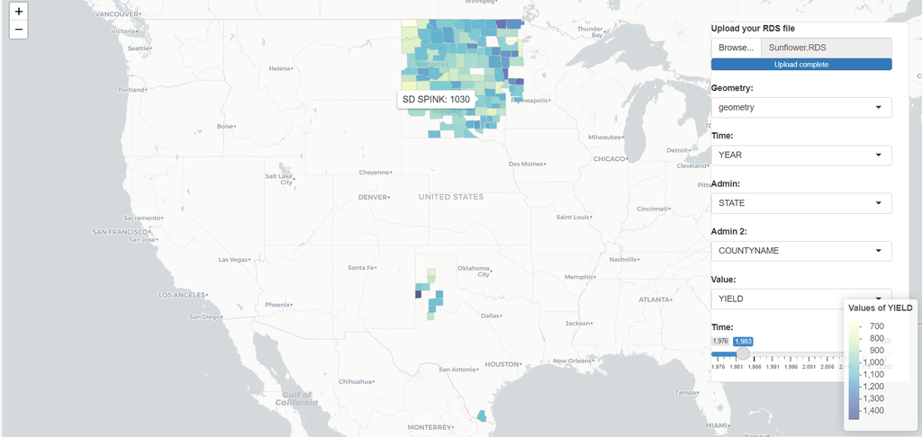

1) The app prompts the user for the file which contains spatial information in the RDS format

2) The user needs to select the column which has the geometry (polygon) information from the dropdown

3) Similarly, columns which have the temporal information (Year, month etc), admin zones 1 and 2 (for example: state followed by county), the value to be visualized (for example seed yield) need to be selected by the user.

4) The app is interactive, which means, the user will be able to know the specific value of yield/area planted/area harvested for any location within the choropleth map